# Esempio Analisi

Livio Finos

05/03/2016

# Intro

Leggo i dati preprocessati e le funzioni per calcolare l’errore:

```r
rm(list=ls())

load("dati_FunScore.Rdata")
```

creo il dataset di test per usarlo in seguito e ridugo `tweets` al solo training set:

```r
set.seed(1)
test=tweets[is.na(tweets$soggettivo),]
dim(test)
```

```
## [1] 1935    8
```

```r
Xtest=X[is.na(tweets$soggettivo),]
dim(Xtest)
```

```
## [1]  1935 15286
```

```r
X=X[!is.na(tweets$soggettivo),]
dim(X)
```

```
## [1]  4513 15286
```

```r
tweets=tweets[!is.na(tweets$soggettivo),]
dim(tweets)
```

```
## [1] 4513    8
```

Mi creo un test set per uso interno estraendolo dal training set:

```r
set.seed(1)
id_test=sample(nrow(tweets),700)
```

# Riduzione della DTM

```r
#le prime tre colonne sono sentiment e ncaratteri:
names(X[,1:8])
```

```
## [1] "sentPOS"                        "sentNEG"
## [3] "nchars"                         "♩♪♬"
## [5] "\U0001f60d\U0001f618✌"          "\u270b\U0001f60f\U0001f612"
## [7] "\U0001f60d\U0001f60d\U0001f60d" "\U0001f602\U0001f602\U0001f602"
```

```r
dim(X)
```

```
## [1]  4513 15286
```

Molte parole sono presenti pochissime volte, ad esempio tengo solo quelle che sono presenti almeno 50 volte

```r
table(colSums(X[,-(1:3)]))
```

```
##
##    0    1    2    3    4    5    6    7    8    9   10   11   12   13   14
## 3316 7976 1572  701  405  281  167  133   91   77   58   52   44   39   35
##   15   16   17   18   19   20   21   22   23   24   25   26   27   28   29
##   27   19   21   10   16   11   10   14   16   13   10   16    6    7   12
##   30   31   32   33   34   35   36   37   38   39   40   41   42   43   44
##    1    2    5    5    8    8    7    1    4    2    2    2    4    1    1
##   45   46   48   49   50   51   52   54   55   57   58   59   60   61   62
##    2    4    1    2    2    1    1    2    2    2    1    1    1    2    1
##   63   64   66   67   68   69   72   73   77   78   79   80   87   90   91
##    1    1    2    2    2    1    2    2    1    2    1    1    1    1    1
##   94   98  100  101  109  115  117  121  123  127  130  145  150  156  172
##    1    1    1    1    1    1    1    1    1    1    1    1    1    1    1
##  174  175  179  258  286  764  793  970  972 1070 1476 1492 1825 3823
##    1    1    1    1    1    1    1    1    1    1    1    1    1    1
```

```r
dtm=X[,-(1:3)]
dtm=dtm[,colSums(dtm)>=50]
X=cbind(X[,1:3],dtm)
dim(X)
```

```
## [1] 4513   69
```

# Modelli di previsione

## Task 1

```r
modlm=lm(tweets$soggettivo[-id_test]~.,data=X[-id_test,])
summary(modlm)
```

```
##
## Call:
## lm(formula = tweets$soggettivo[-id_test] ~ ., data = X[-id_test,
##     ])
##
## Residuals:
##     Min      1Q  Median      3Q     Max
## -1.0773 -0.3475  0.1209  0.2723  1.0636
##
## Coefficients:
##                       Estimate Std. Error t value Pr(>|t|)
## (Intercept)          0.6298549  0.0241119  26.122  < 2e-16 ***
## sentPOSTRUE          0.0723130  0.0168012   4.304 1.72e-05 ***
## sentNEGTRUE          0.1225006  0.0168365   7.276 4.17e-13 ***
## nchars               0.0008382  0.0002357   3.556 0.000382 ***
## ancora              -0.0292939  0.0415985  -0.704 0.481349
## anni                 0.1222365  0.0563194   2.170 0.030038 *
## bello                0.1489307  0.0535769   2.780 0.005467 **
## bene                 0.0719762  0.0366259   1.965 0.049468 *
## berlusconi          -0.0143540  0.0402611  -0.357 0.721469
## cosa                 0.0039441  0.0395517   0.100 0.920573
## crisi               -0.0340371  0.0463007  -0.735 0.462305
## dice                 0.1437253  0.0558530   2.573 0.010112 *
## dire                 0.0821537  0.0619390   1.326 0.184800
## dopo                -0.1028164  0.0409446  -2.511 0.012077 *
## ecco                -0.0759624  0.0601652  -1.263 0.206825
## emoteahah            0.1282738  0.0470616   2.726 0.006447 **
## emotegood            0.1141680  0.0321368   3.553 0.000386 ***
## emotelove            0.0669526  0.0305715   2.190 0.028583 *
## essere               0.0201801  0.0524570   0.385 0.700483
## fare                 0.0048443  0.0342932   0.141 0.887672
## fatto               -0.0634086  0.0350903  -1.807 0.070841 .
## fiducia             -0.0978457  0.0527157  -1.856 0.063518 .
## gente                0.0389985  0.0537177   0.726 0.467891
## governo              0.0085070  0.0361009   0.236 0.813722
## governo_monti        0.1115236  0.0185097   6.025 1.85e-09 ***
## grande               0.0816795  0.0578361   1.412 0.157957
## grazie               0.1096536  0.0411746   2.663 0.007775 **
## grillo               0.0085611  0.0224499   0.381 0.702973
## italia              -0.0564340  0.0272921  -2.068 0.038730 *
```

[output cut: 32 more lines]

```
## video               -0.0706456  0.0611622  -1.155 0.248143
## vita                -0.0461096  0.0436383  -1.057 0.290749
## vuole                0.0234066  0.0611201   0.383 0.701771
## wwwurlwww           -0.3283594  0.0150521 -21.815  < 2e-16 ***
## `Conteggi.\\\\?`    -0.0520262  0.0132245  -3.934 8.50e-05 ***
## `Conteggi.\\\\!`     0.0607215  0.0087655   6.927 5.03e-12 ***
## `Conteggi.@`        -0.0194494  0.0101460  -1.917 0.055321 .
## `Conteggi.#`        -0.0275745  0.0060375  -4.567 5.10e-06 ***
## `Conteggi.(€|euro)`  0.0468947  0.0559391   0.838 0.401906
## ---
## Signif. codes:  0 '***' 0.001 '**' 0.01 '*' 0.05 '.' 0.1 ' ' 1
##
## Residual standard error: 0.4032 on 3743 degrees of freedom
## Multiple R-squared:  0.2201, Adjusted R-squared:  0.2057
## F-statistic: 15.31 on 69 and 3743 DF,  p-value: < 2.2e-16
```

Come scelgo la soglia (il threshold) per la classificazione?

Una proposta tra tante: Quantile della proporzione di zeri (sul training set stimo la stessa proporzione di 1 osservati nel vettore `tweets$obj`). non è detto che sia la scelta migliore (vedi anche dopo).

```r
thr=quantile(predict(modlm),prop.table(table(tweets$soggettivo[-id_test]))[1])
thr
```

```
## 28.69132%
## 0.5866691
```

```r
tab=table( tweets$soggettivo[id_test],predict(modlm,newdata = X[id_test,])>thr)
tab
```

```
##
##         FALSE TRUE
##   FALSE    98   84
##   TRUE     86  432
```

```r
F_soggettivo=F_class(true = tweets$soggettivo[id_test] ,(predict(modlm,newdata = X[id_test,])>thr)==1)
```

```
##    recall precision         F
## 0.8339768 0.8372093 0.8355899
```

```r
F_obj=F_class(true = tweets$soggettivo[id_test]==0 ,(predict(modlm,newdata = X[id_test,])>thr)==0)
```

```
##    recall precision         F
## 0.5384615 0.5326087 0.5355191
```

```r
(F_obj+F_soggettivo)/2
```

```
## [1] 0.6855545
```

### Creazione previsioni dataset Test

```r
yhat=predict(modlm,newdata = Xtest[,])>thr
write.table(file='predicted_task1.txt', yhat)
```

## Task2: polarity classification

Modello per prevedere `positivo`

```r
modlm_pos=lm(tweets$positivo[-id_test]~.,data=X[-id_test,])
summary(modlm_pos)
```

```
##
## Call:
## lm(formula = tweets$positivo[-id_test] ~ ., data = X[-id_test,
##     ])
##
## Residuals:
##     Min      1Q  Median      3Q     Max
## -0.8776 -0.2697 -0.1396  0.3006  1.0435
##
## Coefficients:
##                       Estimate Std. Error t value Pr(>|t|)
## (Intercept)          0.2399954  0.0242584   9.893  < 2e-16 ***
## sentPOSTRUE          0.1735761  0.0169032  10.269  < 2e-16 ***
## sentNEGTRUE         -0.0818738  0.0169387  -4.834 1.40e-06 ***
## nchars              -0.0001597  0.0002372  -0.673 0.500710
## ancora              -0.0254051  0.0418512  -0.607 0.543865
## anni                 0.0014924  0.0566616   0.026 0.978988
## bello                0.1819104  0.0539024   3.375 0.000746 ***
## bene                 0.1555856  0.0368484   4.222 2.48e-05 ***
## berlusconi          -0.0126923  0.0405057  -0.313 0.754035
## cosa                -0.0196737  0.0397919  -0.494 0.621043
## crisi                0.1274181  0.0465819   2.735 0.006261 **
## dice                 0.0436902  0.0561923   0.778 0.436905
## dire                 0.1367776  0.0623153   2.195 0.028230 *
## dopo                -0.0049907  0.0411933  -0.121 0.903576
## ecco                -0.1110587  0.0605307  -1.835 0.066622 .
## emoteahah            0.2749241  0.0473475   5.807 6.91e-09 ***
## emotegood            0.2067706  0.0323320   6.395 1.80e-10 ***
## emotelove            0.1258286  0.0307572   4.091 4.39e-05 ***
## essere               0.0816964  0.0527757   1.548 0.121709
## fare                -0.0003363  0.0345015  -0.010 0.992224
## fatto                0.0544390  0.0353034   1.542 0.123150
## fiducia             -0.0406133  0.0530359  -0.766 0.443861
## gente               -0.1287077  0.0540441  -2.382 0.017290 *
## governo              0.0462881  0.0363202   1.274 0.202585
## governo_monti        0.0213395  0.0186221   1.146 0.251900
## grande               0.1035190  0.0581875   1.779 0.075311 .
## grazie               0.2706378  0.0414247   6.533 7.30e-11 ***
## grillo              -0.0563106  0.0225863  -2.493 0.012705 *
## italia               0.0362312  0.0274579   1.320 0.187077
```

[output cut: 32 more lines]

```
## video               -0.0593108  0.0615338  -0.964 0.335171
## vita                 0.0621036  0.0439034   1.415 0.157284
## vuole               -0.1252577  0.0614914  -2.037 0.041721 *
## wwwurlwww           -0.0814902  0.0151435  -5.381 7.85e-08 ***
## `Conteggi.\\\\?`    -0.0927700  0.0133049  -6.973 3.66e-12 ***
## `Conteggi.\\\\!`     0.0712771  0.0088188   8.082 8.49e-16 ***
## `Conteggi.@`         0.0428411  0.0102077   4.197 2.77e-05 ***
## `Conteggi.#`        -0.0075981  0.0060742  -1.251 0.211053
## `Conteggi.(€|euro)` -0.0362024  0.0562789  -0.643 0.520090
## ---
## Signif. codes:  0 '***' 0.001 '**' 0.01 '*' 0.05 '.' 0.1 ' ' 1
##
## Residual standard error: 0.4056 on 3743 degrees of freedom
## Multiple R-squared:  0.2153, Adjusted R-squared:  0.2008
## F-statistic: 14.88 on 69 and 3743 DF,  p-value: < 2.2e-16
```

```r
# tab=table( tweets$positivo[id_test],predict(modlm_pos,newdata = X[id_test,])>.5)
thr_pos=quantile(predict(modlm_pos),prop.table(table(tweets$positivo[-id_test]))[1])
thr_pos
```

```
## 71.02019%
##  0.376487
```

```r
tab=table( tweets$positivo[id_test],predict(modlm_pos,newdata = X[id_test,])>thr_pos)

tab
```

```
##
##         FALSE TRUE
##   FALSE   407  106
##   TRUE     91   96
```

```r
F_pos_1=F_class( tweets$positivo[id_test]==1,(predict(modlm_pos,newdata = X[id_test,])>thr)==1)
```

```
##    recall precision         F
## 0.2352941 0.6376812 0.3437500
```

```r
F_pos_0=F_class( tweets$positivo[id_test]==0,(predict(modlm_pos,newdata = X[id_test,])>thr)==0)
```

```
##    recall precision         F
## 0.9512671 0.7733756 0.8531469
```

Modello per prevedere `negativo`

```r
modlm_neg=lm(tweets$negativo[-id_test]~.,data=X[-id_test,])
summary(modlm_neg)
```

```
##
## Call:
## lm(formula = tweets$negativo[-id_test] ~ ., data = X[-id_test,
##     ])
##
## Residuals:
##     Min      1Q  Median      3Q     Max
## -1.1934 -0.3529 -0.1295  0.4211  1.2023
##
## Coefficients:
##                       Estimate Std. Error t value Pr(>|t|)
## (Intercept)          2.734e-01  2.678e-02  10.209  < 2e-16 ***
## sentPOSTRUE         -8.906e-02  1.866e-02  -4.772 1.89e-06 ***
## sentNEGTRUE          1.931e-01  1.870e-02  10.328  < 2e-16 ***
## nchars               1.972e-03  2.618e-04   7.532 6.21e-14 ***
## ancora              -2.194e-02  4.621e-02  -0.475 0.634912
## anni                 1.854e-01  6.256e-02   2.964 0.003052 **
## bello                3.565e-02  5.951e-02   0.599 0.549170
## bene                 1.666e-02  4.068e-02   0.409 0.682222
## berlusconi          -4.369e-02  4.472e-02  -0.977 0.328631
## cosa                -7.706e-03  4.393e-02  -0.175 0.860767
## crisi               -8.162e-02  5.143e-02  -1.587 0.112587
## dice                 1.926e-01  6.204e-02   3.104 0.001922 **
## dire                 1.020e-01  6.880e-02   1.483 0.138273
## dopo                -7.399e-02  4.548e-02  -1.627 0.103849
## ecco                -3.676e-02  6.683e-02  -0.550 0.582353
## emoteahah           -8.987e-02  5.227e-02  -1.719 0.085674 .
## emotegood           -7.733e-02  3.570e-02  -2.166 0.030357 *
## emotelove           -3.583e-02  3.396e-02  -1.055 0.291372
## essere              -7.376e-02  5.827e-02  -1.266 0.205629
## fare                -1.183e-02  3.809e-02  -0.310 0.756205
## fatto               -5.624e-02  3.898e-02  -1.443 0.149156
## fiducia             -4.407e-02  5.855e-02  -0.753 0.451765
## gente                3.582e-05  5.967e-02   0.001 0.999521
## governo              5.481e-02  4.010e-02   1.367 0.171764
## governo_monti        1.134e-01  2.056e-02   5.516 3.70e-08 ***
## grande               3.156e-02  6.424e-02   0.491 0.623221
## grazie              -9.779e-02  4.574e-02  -2.138 0.032572 *
## grillo               9.407e-02  2.494e-02   3.772 0.000164 ***
## italia              -4.168e-02  3.032e-02  -1.375 0.169224
```

[output cut: 32 more lines]

```
## video               -1.848e-02  6.794e-02  -0.272 0.785625
## vita                -6.270e-02  4.847e-02  -1.293 0.195943
## vuole                3.940e-02  6.789e-02   0.580 0.561712
## wwwurlwww           -2.388e-01  1.672e-02 -14.281  < 2e-16 ***
## `Conteggi.\\\\?`    -1.383e-02  1.469e-02  -0.942 0.346424
## `Conteggi.\\\\!`     1.253e-02  9.736e-03   1.287 0.198091
## `Conteggi.@`        -6.281e-02  1.127e-02  -5.573 2.68e-08 ***
## `Conteggi.#`        -2.702e-02  6.706e-03  -4.029 5.71e-05 ***
## `Conteggi.(€|euro)` -3.408e-02  6.214e-02  -0.549 0.583372
## ---
## Signif. codes:  0 '***' 0.001 '**' 0.01 '*' 0.05 '.' 0.1 ' ' 1
##
## Residual standard error: 0.4478 on 3743 degrees of freedom
## Multiple R-squared:  0.2008, Adjusted R-squared:  0.186
## F-statistic: 13.63 on 69 and 3743 DF,  p-value: < 2.2e-16
```

```r
# tab=table( tweets$negativo[id_test],predict(modlm_neg,newdata = X[id_test,])>.5)
thr_neg=quantile(predict(modlm_neg),prop.table(table(tweets$negativo[-id_test]))[1])
thr_neg
```

```
## 56.07133%
## 0.4622407
```

```r
tab=table( tweets$negativo[id_test],predict(modlm_neg,newdata = X[id_test,])>thr_neg)

tab
```

```
##
##         FALSE TRUE
##   FALSE   250  124
##   TRUE    116  210
```

```r
F_neg_1=F_class( tweets$negativo[id_test]==1,(predict(modlm_neg,newdata = X[id_test,])>thr)==1)
```

```
##    recall precision         F
## 0.4018405 0.6931217 0.5087379
```

```r
F_neg_0=F_class( tweets$negativo[id_test]==0,(predict(modlm_neg,newdata = X[id_test,])>thr)==0)
```

```
##    recall precision         F
## 0.8449198 0.6183953 0.7141243
```

Punteggio stimato sul test set:

```r
((F_neg_0+F_neg_1)/2+(F_pos_0+F_pos_1)/2)/2
```

```
## [1] 0.6049398
```

### Creazione previsioni dataset Test

```r
yhat=cbind(predict(modlm_pos,newdata = Xtest)>thr_pos,
           predict(modlm_neg,newdata = Xtest)>thr_neg)
str(yhat)
```

```
##  logi [1:1935, 1:2] TRUE FALSE FALSE FALSE FALSE FALSE ...
##  - attr(*, "dimnames")=List of 2
##   ..$ : chr [1:1935] "4514" "4515" "4516" "4517" ...
##   ..$ : NULL
```

```r
write.table(file='predicted_task2.txt', yhat,row.names = FALSE,col.names = FALSE)
```

## Task 3

```r
modlm=lm(tweets$iro[-id_test]~.,data=X[-id_test,])
summary(modlm)
```

```
##
## Call:
## lm(formula = tweets$iro[-id_test] ~ ., data = X[-id_test, ])
##
## Residuals:
##      Min       1Q   Median       3Q      Max
## -0.45010 -0.16312 -0.09214 -0.00378  1.09441
##
## Coefficients:
##                       Estimate Std. Error t value Pr(>|t|)
## (Intercept)          0.0886676  0.0188429   4.706 2.62e-06 ***
## sentPOSTRUE         -0.0057102  0.0131297  -0.435 0.663656
## sentNEGTRUE          0.0023492  0.0131573   0.179 0.858304
## nchars               0.0007154  0.0001842   3.884 0.000105 ***
## ancora              -0.0503908  0.0325082  -1.550 0.121203
## anni                -0.0241102  0.0440122  -0.548 0.583858
## bello                0.0094012  0.0418690   0.225 0.822350
## bene                -0.0689395  0.0286222  -2.409 0.016062 *
## berlusconi          -0.0139541  0.0314630  -0.444 0.657423
## cosa                -0.0264555  0.0309086  -0.856 0.392093
## crisi               -0.0058110  0.0361828  -0.161 0.872417
## dice                 0.1112841  0.0436477   2.550 0.010824 *
## dire                 0.0593107  0.0484038   1.225 0.220527
## dopo                 0.0287964  0.0319971   0.900 0.368196
## ecco                 0.0252829  0.0470176   0.538 0.590793
## emoteahah            0.0817298  0.0367774   2.222 0.026324 *
## emotegood            0.0185120  0.0251141   0.737 0.461099
## emotelove           -0.0166101  0.0238908  -0.695 0.486942
## essere              -0.0629118  0.0409938  -1.535 0.124950
## fare                -0.0089992  0.0267992  -0.336 0.737040
## fatto               -0.0247464  0.0274222  -0.902 0.366890
## fiducia             -0.0243686  0.0411960  -0.592 0.554201
## gente               -0.0070980  0.0419790  -0.169 0.865740
## governo             -0.0328609  0.0282119  -1.165 0.244179
## governo_monti        0.0887621  0.0144648   6.136 9.32e-10 ***
## grande              -0.0602962  0.0451974  -1.334 0.182264
## grazie              -0.0579396  0.0321769  -1.801 0.071837 .
## grillo              -0.0364352  0.0175440  -2.077 0.037890 *
## italia              -0.0547909  0.0213281  -2.569 0.010239 *
## italiani             0.0434901  0.0418587   1.039 0.298885
```

[output cut: 31 more lines]

```
## video               -0.0707529  0.0477967  -1.480 0.138881
## vita                -0.0212918  0.0341022  -0.624 0.532434
## vuole               -0.0483609  0.0477638  -1.013 0.311363
## wwwurlwww           -0.1628698  0.0117628 -13.846  < 2e-16 ***
## `Conteggi.\\\\?`     0.0230279  0.0103346   2.228 0.025924 *
## `Conteggi.\\\\!`     0.0080553  0.0068500   1.176 0.239686
## `Conteggi.@`        -0.0317905  0.0079289  -4.009 6.20e-05 ***
## `Conteggi.#`        -0.0048099  0.0047181  -1.019 0.308057
## `Conteggi.(€|euro)`  0.0819679  0.0437149   1.875 0.060863 .
## ---
## Signif. codes:  0 '***' 0.001 '**' 0.01 '*' 0.05 '.' 0.1 ' ' 1
##
## Residual standard error: 0.3151 on 3743 degrees of freedom
## Multiple R-squared:  0.1113, Adjusted R-squared:  0.09491
## F-statistic: 6.793 on 69 and 3743 DF,  p-value: < 2.2e-16
```

```r
thr=quantile(predict(modlm),prop.table(table(tweets$iro[-id_test]))[1])
thr
```

```
## 87.46394%
## 0.2602651
```

```r
tab=table( tweets$iro[id_test],predict(modlm,newdata = X[id_test,])>thr)
tab
```

```
##
##         FALSE TRUE
##   FALSE   544   66
##   TRUE     60   30
```

```r
F_iro=F_class(true = tweets$iro[id_test]==1 ,(predict(modlm,newdata = X[id_test,])>thr)==1)
```

```
##    recall precision         F
## 0.3333333 0.3125000 0.3225806
```

```r
F_noiro=F_class(true = tweets$iro[id_test]==0 ,(predict(modlm,newdata = X[id_test,])>thr)==0)
```

```
##    recall precision         F
## 0.8918033 0.9006623 0.8962109
```

```r
(F_iro+F_noiro)/2
```

```
## [1] 0.6093958
```

### Creazione previsioni dataset Test

```r
yhat=predict(modlm,newdata = Xtest[,])>thr
write.table(file='predicted_task3.txt', yhat)
```

# Come scegliere tra diversi modelli?

Come scegliere il miglior modello tra diversi possibili?

Sappiamo che onfrontare gli indici calcolati sugli stessi dati su cui abbiamo stimato i parametri del modello non è una buona idea…

Cosa proponete?

# EXTRA

Posso provare a migliorare il risultato ottimizzando il threshold (Es Task 3):

*ATTENZIONE* su quale dataset ottimizzo il threshold??

```r
# ne faccio una funzione
getScore <- function(thr){
  F_iro=F_class(true = tweets$iro[-id_test] ,(predict(modlm)>thr)==1,verbatim=FALSE)
  F_noiro=F_class(true = tweets$iro[-id_test]==0 ,(predict(modlm)>thr)==0,verbatim=FALSE)
  (F_iro+F_noiro)/2
  }


range(predict(modlm))
```

```
## [1] -0.5918353  0.5361353
```

```r
#lo riduco un po':
limiti_valori_da_provare=range(predict(modlm))*.9
valori_da_provare=seq(limiti_valori_da_provare[1],limiti_valori_da_provare[2],length.out = 20)

scores=sapply(valori_da_provare,getScore)

results=cbind(thr=valori_da_provare,scoreTrain=scores)
results
```

```
##                thr scoreTrain
##  [1,] -0.532651752  0.1117217
##  [2,] -0.479221565  0.1117217
##  [3,] -0.425791378  0.1117217
##  [4,] -0.372361192  0.1117217
##  [5,] -0.318931005  0.1117217
##  [6,] -0.265500818  0.1117217
##  [7,] -0.212070632  0.1133478
##  [8,] -0.158640445  0.1178788
##  [9,] -0.105210258  0.1312805
## [10,] -0.051780071  0.1688751
## [11,]  0.001650115  0.2431069
## [12,]  0.055080302  0.3486290
## [13,]  0.108510489  0.4966426
## [14,]  0.161940675  0.5993335
## [15,]  0.215370862  0.6493345
## [16,]  0.268801049  0.6460787
## [17,]  0.322231235  0.5770578
## [18,]  0.375661422  0.5009859
## [19,]  0.429091609  0.4748487
## [20,]  0.482521795  0.4687170
```

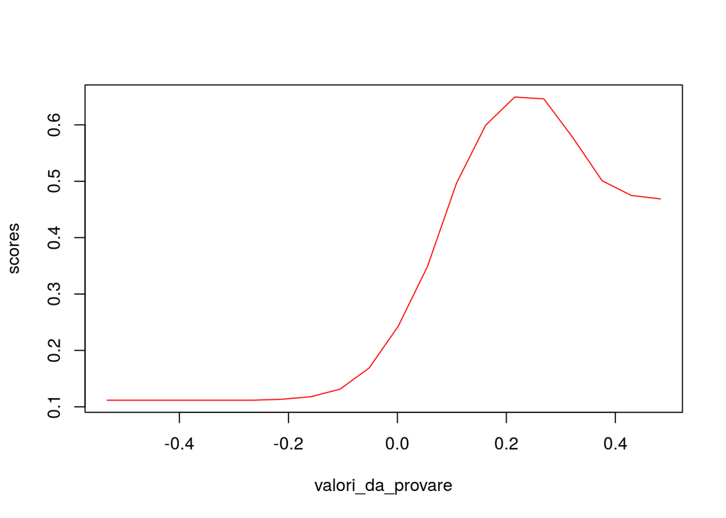

```r
plot(valori_da_provare,scores,type = "l",col=2)
```

```r
max(scores,na.rm = TRUE)
```

```
## [1] 0.6493345
```

```r
thr=valori_da_provare[which.max(scores)]
thr
```

```
## [1] 0.2153709
```

ora lo provo sul test set!

```r
F_iro=F_class(true = tweets$iro[id_test]==1 ,(predict(modlm,newdata = X[id_test,])>thr)==1,verbatim=FALSE)
F_noiro=F_class(true = tweets$iro[id_test]==0 ,(predict(modlm,newdata = X[id_test,])>thr)==0,verbatim=FALSE)
(F_iro+F_noiro)/2
```

```
## [1] 0.5949499
```

- Calcoliamo l’errore solo per questo threshold. se cercassi il massimo incorrerei in distorsione nella stima (stimo il max tra molti)

A titolo di curiosità calcolo gli errori per i diversi treshold sul test set:

```r
getScoreTest <- function(thr){
  F_iro=F_class(true = tweets$iro[id_test]==1 ,(predict(modlm,newdata = X[id_test,])>thr)==1,verbatim=FALSE)
  F_noiro=F_class(true = tweets$iro[id_test]==0 ,(predict(modlm,newdata = X[id_test,])>thr)==0,verbatim=FALSE)
  (F_iro+F_noiro)/2
}

scoresTest=sapply(valori_da_provare,getScoreTest)

results=cbind(results, scoreTest=scoresTest)
results
```

```
##                thr scoreTrain scoreTest
##  [1,] -0.532651752  0.1117217       NaN
##  [2,] -0.479221565  0.1117217       NaN
##  [3,] -0.425791378  0.1117217       NaN
##  [4,] -0.372361192  0.1117217       NaN
##  [5,] -0.318931005  0.1117217       NaN
##  [6,] -0.265500818  0.1117217 0.1157051
##  [7,] -0.212070632  0.1133478 0.1227798
##  [8,] -0.158640445  0.1178788 0.1297765
##  [9,] -0.105210258  0.1312805 0.1384153
## [10,] -0.051780071  0.1688751 0.1799327
## [11,]  0.001650115  0.2431069 0.2456897
## [12,]  0.055080302  0.3486290 0.3403814
## [13,]  0.108510489  0.4966426 0.4778185
## [14,]  0.161940675  0.5993335 0.5953356
## [15,]  0.215370862  0.6493345 0.5949499
## [16,]  0.268801049  0.6460787 0.6102951
## [17,]  0.322231235  0.5770578 0.5431607
## [18,]  0.375661422  0.5009859 0.5251488
## [19,]  0.429091609  0.4748487       NaN
## [20,]  0.482521795  0.4687170       NaN
```

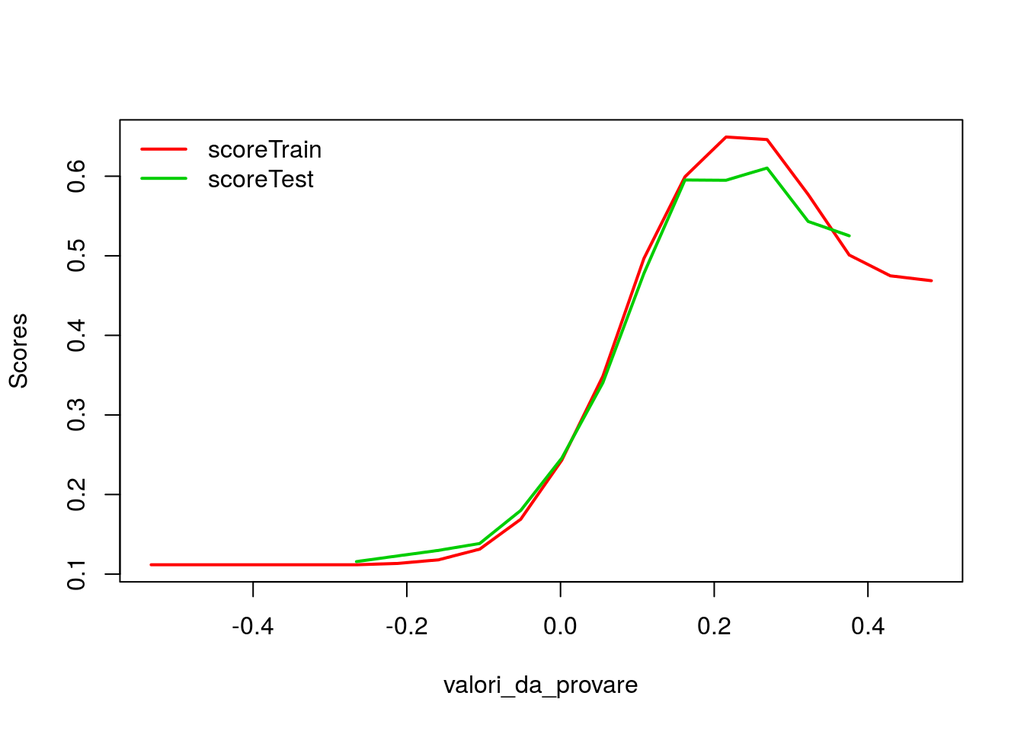

```r
matplot(valori_da_provare,results[,-1],type = "l",col=2:3,lty=1,lwd=2,ylab="Scores")
legend("topleft",legend = colnames(results)[-1],lwd=2,lty=1,col=2:3,bty="n")
```